# Red and Purple Urchin Size and Purple Urchin Population Count

Kiera Matiska

10/23/2021

# Objective

This code looks at data on red and purple sea urchin. The first section compares the body size of the two different urchins. The second section counts the number of purple urchins that are found at each site from the year 2008 to 2020. This code wrangles data and used graphs to visualize it.

### Source:

Reed, D. 2020. SBC LTER: Reef: Long-term experiment: Kelp removal: Urchin size frequency distribution ver 20. Environmental Data Initiative. https://doi.org/10.6073/pasta/5a1e9ef03aa47bd2225c0bb98a02a63b.

```r
knitr::opts_chunk$set(echo = TRUE, message = FALSE, warning = FALSE)

# Add packages
library(tidyverse)
library(here)
library(janitor)
library(kableExtra)
library(lubridate)
```

# Read in urchins.csv and clean up column names

- Use the function read_csv() to read in the data
- Use the fuction clean_names() to change column headers to lower-snake case

```r
urchins <- read_csv(here("data", "urchins.csv"))

urchins_clean <- urchins %>%
  clean_names()
```

# Section 1: Size Comparisons

### Data Wrangling

Use select() to select the columns size and common_name create a new data frame.

```r
urchins_size <- urchins_clean %>%
  select(common_name, size)
```

### Data visualization

Using ggplot(), create a histogram using geom_histogram to compare the distribution of sizes between red and purple urchins: - Reduce number of bins to ~10 - Add a caption figure

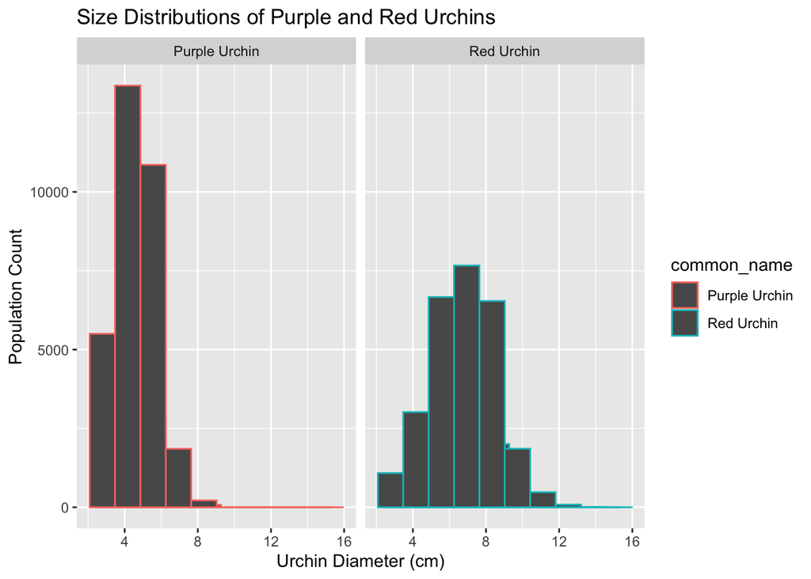

```r
ggplot(data = urchins_size,
       aes(x = size, color = common_name)) +
  geom_histogram() + # Try to figure out how to add color
  facet_grid(~ common_name) +
  stat_bin(bins = 10) +
  labs(title = "Size Distributions of Purple and Red Urchins",
      x = "Urchin Diameter (cm)",
      y = "Population Count")
```

Figure 1: Size Distributions of Purple and Red Urchins. Sizes are measured using centimeter on sea urchins within this sample.

### Statistical Analyisis

Using summarize() create a summary table for purple and red sea urchins. Table should include: - mean - median - standard deviation - sample size

Use kableExtra to finalize table for knitted document and add a table caption above the table.

```r
urchin_size_sum <- urchins_size %>%
  group_by(common_name) %>%
  summarize(mean(size),
            median(size),
            sd(size),
            sample_size = n())

urchin_size_sum %>%
  kbl(caption = "Table 1: Statistical data, including mean, median, standard deviation, and sample size, of purple and red sea urchin sizes") %>%
  kable_styling()
```

Table 1: Statistical data, including mean, median, standard deviation, and sample size, of purple and red sea urchin sizes

| common_name | mean(size) | median(size) | sd(size) | sample_size |
| --- | --- | --- | --- | --- |
| Purple Urchin | 4.469797 | 4.5 | 1.175264 | 31805 |
| Red Urchin | 6.776489 | 7.0 | 1.891343 | 27408 |

### Key takeaways

On average, red urchins appear to be larger in size than purple urchins. The overall spread for red urchins is also much larger than the spread of purple urchins, therefore possibly indicating that red urchins have more variations in sizes. The average size of each sample is 4.47 cm for purple urchins and 6.78 for red urchins, therefore showing that red urchins are, on average, greater than 2 cm larger than purple urchins.

# Section 2: Explore purple urchin counts for each site in each year

### Wrangle Data

Create a new data frame called purple_urchins.

Use a piped sequence to: - Filter for observations that only contain purple urchin using filter() - Convert date column to class date using myd() in the lubridate package - Using mutate(), create a new column containing only year - Using mutate(), create another new column called site_full that contains the full name of all the sites

```r
purple_urchin <- urchins_clean %>%
  filter(common_name == "Purple Urchin") %>%
  mutate(date = mdy(date)) %>%
  mutate(year = year(date)) %>%
  mutate(site_full = case_when(
    site == "NAPL" ~ "Naples Reef",
    site == "AQUE" ~ "Arroyo Quemado Reef",
    site == "CARP" ~ "Carpinteria Reef",
    site == "MOHK" ~ "Mohawk Reef",
    site == "IVEE" ~ "Isla Vista Reef"))
```

### Visualize Data

Create a graph: - include counts of purple urchins per year - facet by sites - add a figure caption

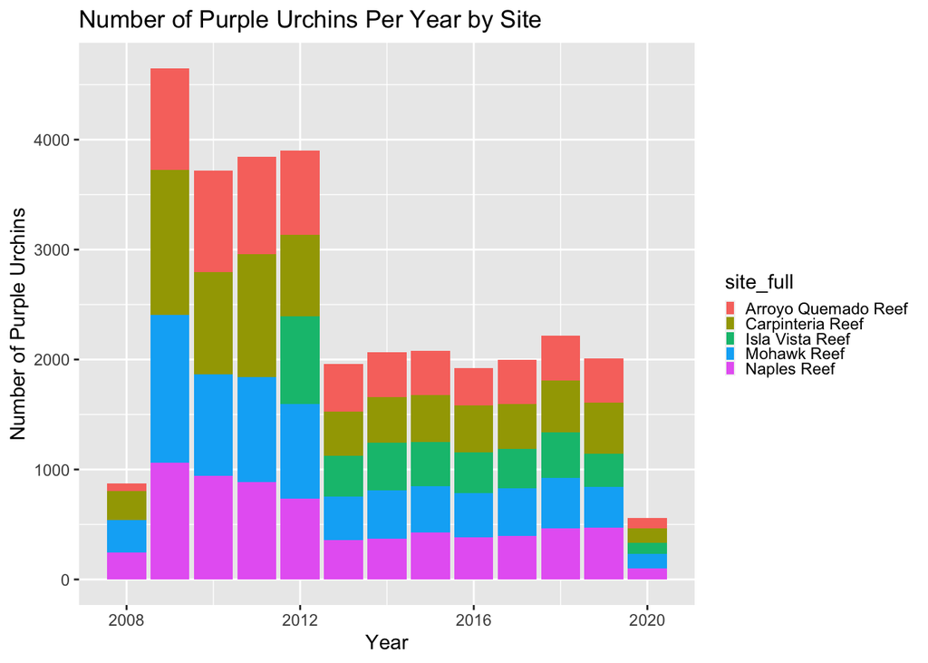

```r
ggplot(data = site_num,
       aes(x = year, y = sample_size)) +
  geom_col(aes(fill = site_full)) +
  theme(legend.key.size = unit(0.2, 'cm')) +
  labs(title = "Number of Purple Urchins Per Year by Site",
       x = "Year",
       y = "Number of Purple Urchins")
```

Figure 2: Number of Purple Urchins Per Year by Site. Separated by 5 sites (Naples Reef, Arroyo Quemado Reef, Carpenteria Reef, Mohawk Reef, and Isla Vista Reef), the number of individuals of purple urchins is examined by year from 2008 to 2020.

I think that this graph does represent changes in the purple urchin population from 2008 to 2020, however that might not be the case. Because urchins are found underwater and along reefs, sometimes they may be hard to find and count, therefore there is always a chance of error when counting underwater species. Other things that could cause the changes viewed above could be environmental changes or reef health.